GJG 06/06/2026 RGC Spatial locations

Here, I am going to see if our RGC subclusters correspond to spatially distinct populations of RGCs. One caveat here this will not be dissection aware while I wait to hear back from Coltan re: which parts of sections should be excluded.

The steps will be 1) Subset visium object to be ONLY RGCs as defined by expression of markers gfap, LOC111577263, sox2, or gja1b 1a) Run SCT on visium RGC object 2) Subset multiome object and subcluster 2a) Because ependymal cells are also gfap+ and crocc2, the main marker, does not appear very strongly in the visium data, I will also include them 2b) 26, a dividing glial cluster will also be included 3) Use Seurat’s label transfer functionality to go multiome_RGC -> Spatial data 4) Make a heatmap of regions 5) Plot on spatial

From prior knowledge, I hypothesize that 1_shha, 1_NSC, and 1_NP will be along the medial ventricles while 1_gfap will be more filamentous.

Libraries

Read in visium data

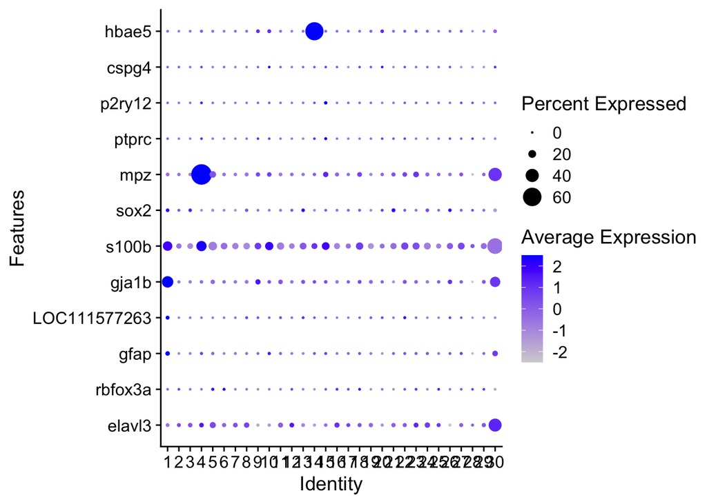

```r
# ── 1. Load ──────────────────────────────────────────────────────────────────
vis <- readRDS('/Users/ggraham/Desktop/Visium/vis.rds')

# ── 2. Anatomical labels ──────────────────────────────────────────────────────
barcodes <- list.files(
  '/Users/ggraham/Desktop/multiome_poa/Visium/Groupings/Maruska Regions Data Informed/',
  full.names = TRUE
) %>%
  lapply(read.csv) %>%
  bind_rows()

ana <- setNames(barcodes$Anatomical, barcodes$Barcode)
seurat_barcodes <- gsub("_[0-9]+$", "", Cells(vis))
vis$anatomical <- unname(ana[seurat_barcodes])

# ── 4. Non-neuronal clusters (from marker genes) ─────────────────────────────
Idents(vis) <- 'seurat_clusters.projected0.4'
DotPlot(vis, features = c('elavl3','rbfox3a','gfap','LOC111577263','gja1b',
                          's100b','sox2',
                           'mpz','ptprc','p2ry12','cspg4','hbae5')) +
  coord_flip()
```

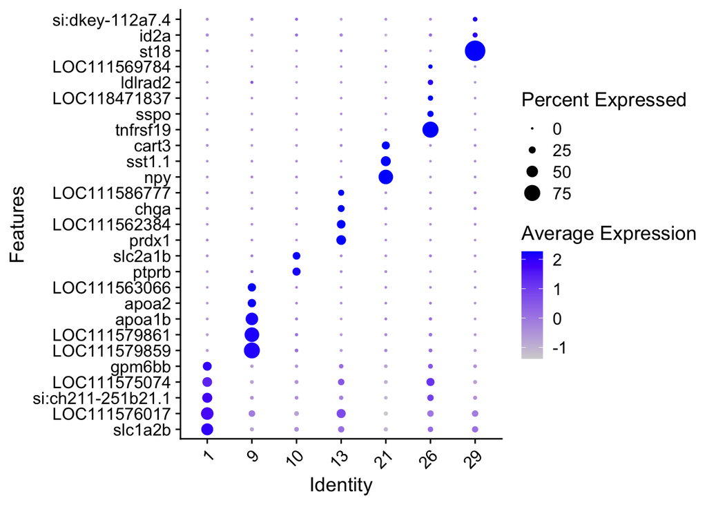

```r
# Top 5 markers per cluster by p_val_adj
top5 <- marks %>%
  filter(p_val_adj < 0.05) %>%
  group_by(cluster) %>%
  slice_min(order_by = p_val_adj, n = 5, with_ties = FALSE) %>%
  ungroup()

# DotPlot
DotPlot(
  vis_rgc_test,
  features = unique(top5$gene),
  group.by = "seurat_clusters.projected0.4"
) +
  coord_flip() +
  theme(axis.text.x = element_text(angle = 45, hjust = 1))
```

1 is certainly a radial glia 9 I’m not sure none of its markers show up in the featureplot of the multiome object 10 is ependymal cells probably, 13 is like a new neuron or something 21 is a neuron, actually its vsst lol 26 looks like a rgc 29 is not

Evidence for above^^

```r
obj <- readRDS('~/Desktop/optimal_clustering_rna_only.rds')
```

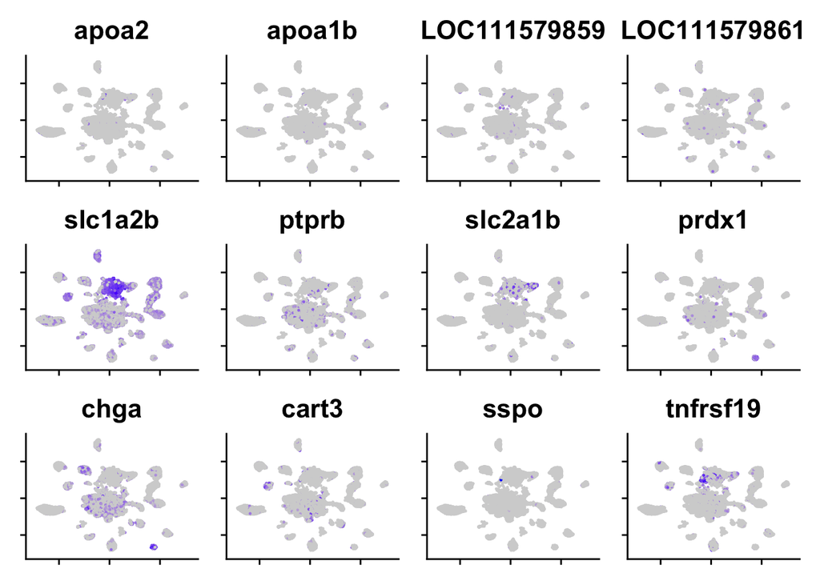

```r
FeaturePlot(obj, c('apoa2',
                   'apoa1b',
                   'LOC111579859',
                   'LOC111579861',
                   'slc1a2b',
                   'ptprb',
                   'slc2a1b',
                   'prdx1',
                   'chga',
                   'cart3',
                   'sspo',
                   'tnfrsf19'), reduction = 'harmony_wnn.umap'
            ) & NoLegend() &
  theme(axis.title = element_blank(),
        axis.text = element_blank())
```

Subset visium object

Run SCT, save

Subset and subcluster ependymoglia

```
## Modularity Optimizer version 1.3.0 by Ludo Waltman and Nees Jan van Eck
##
## Number of nodes: 3711
## Number of edges: 993447
##
## Running Louvain algorithm...
## Maximum modularity in 10 random starts: 0.8591
## Number of communities: 5
## Elapsed time: 1 seconds
```

```
## 1 singletons identified. 4 final clusters.
```

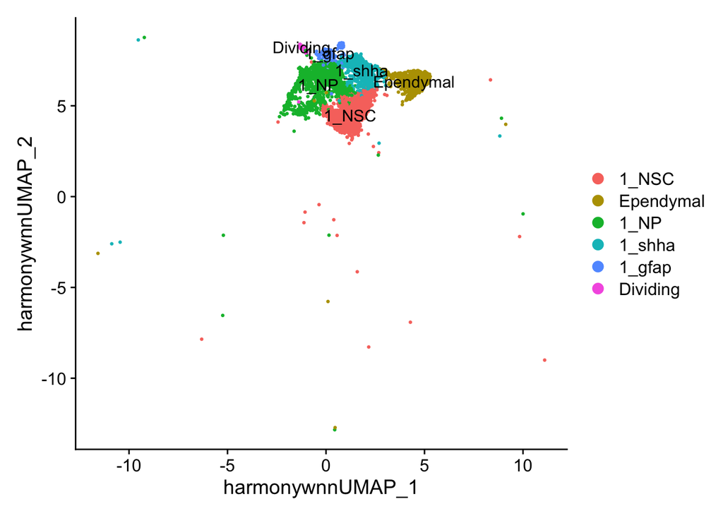

Perfect, now, label transfer time

Balance object so that larger populations do not overwhelm the transfer

```r
cells_per_cluster <- 200

set.seed(42)
cells_keep <- obj_rgc@meta.data %>%
  tibble::rownames_to_column("cell") %>%
  group_by(sub_res0.2) %>%
  group_modify(~ slice_sample(.x, n = min(cells_per_cluster, nrow(.x)))) %>%
  pull(cell)


obj_rgc_balanced <- subset(obj_rgc, cells = cells_keep)
```

```r
vis_rgc$seurat_clusters.projected0.4 = droplevels(vis_rgc$seurat_clusters.projected0.4 )
# score distribution split by whether assignment was high confidence
vis_rgc$transfer_confident <-
  vis_rgc$predicted.transferred_cluster.score > 0.5

cat("\nHigh confidence assignments:",
    sum(vis_rgc$transfer_confident), "\n")
```

```
##
## High confidence assignments: 54380
```

```r
cat("Low confidence assignments:",
    sum(!vis_rgc$transfer_confident), "\n")
```

```
## Low confidence assignments: 23977
```

Very good confidence

Plot against visium clusters

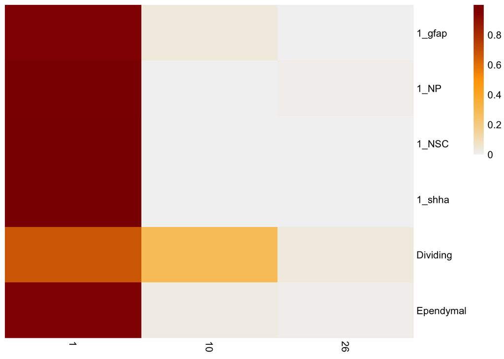

```r
  vis_rgc$predicted.cluster=   vis_rgc$predicted.transferred_cluster[vis_rgc$transfer_confident==T]

agreement = table(vis_rgc$predicted.cluster,
                  vis_rgc$seurat_clusters.projected0.4)

pheatmap(
  agreement / rowSums(agreement),               # each region sums to 1
  cluster_rows = F,
  cluster_cols = F,
  border_color = NA,
  color        = colorRampPalette(c("grey95", "orange", "darkred"))(100)
)
```

Is there a spatial difference

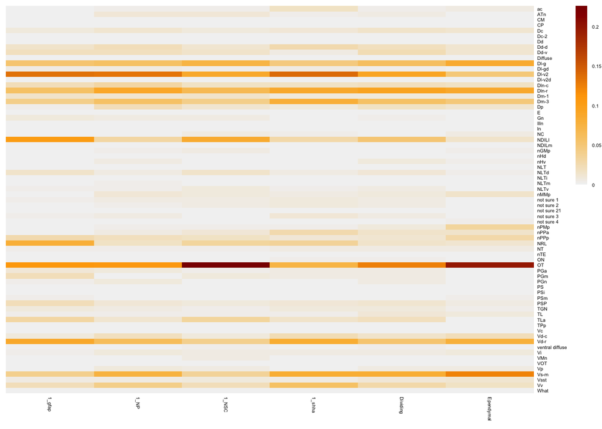

```r
renamed = c(
  'could be nPPa'= 'What',
  'could be nMMp' = 'nMMp',
  'could be nPMP' = 'nPMp',
  'dorsolateral nucleus' = 'Dln-r',
  'dorsolateral nucleus caudal part' = 'Dln-c',
  'Dl-v2 dorsal part' = 'Dl-v2d',
  'TGn' = 'TGN'
)

renaming_col = ifelse(vis_rgc$anatomical %in% c(names(renamed)), renamed[vis_rgc$anatomical], vis_rgc$anatomical)
vis_rgc$anatomical_renamed = renaming_col

  vis_rgc$predicted.cluster=   vis_rgc$predicted.transferred_cluster[vis_rgc$transfer_confident==T]

agreement = table(vis_rgc$predicted.cluster,
                  vis_rgc$anatomical_renamed)

pheatmap(
  t(agreement / rowSums(agreement)),               # each region sums to 1
  cluster_rows = F,
  cluster_cols = F,
  border_color = NA,
  color        = colorRampPalette(c("grey95", "orange", "darkred"))(100),
  fontsize=4)
```

Visually, a lot of confidence for the rgcs in OT which isnt surprising because there is so many of them there that I guess it is much more confident. In POA, seems to be more ependymal cells and 1_2 which is 1_shha, lets just plot it though

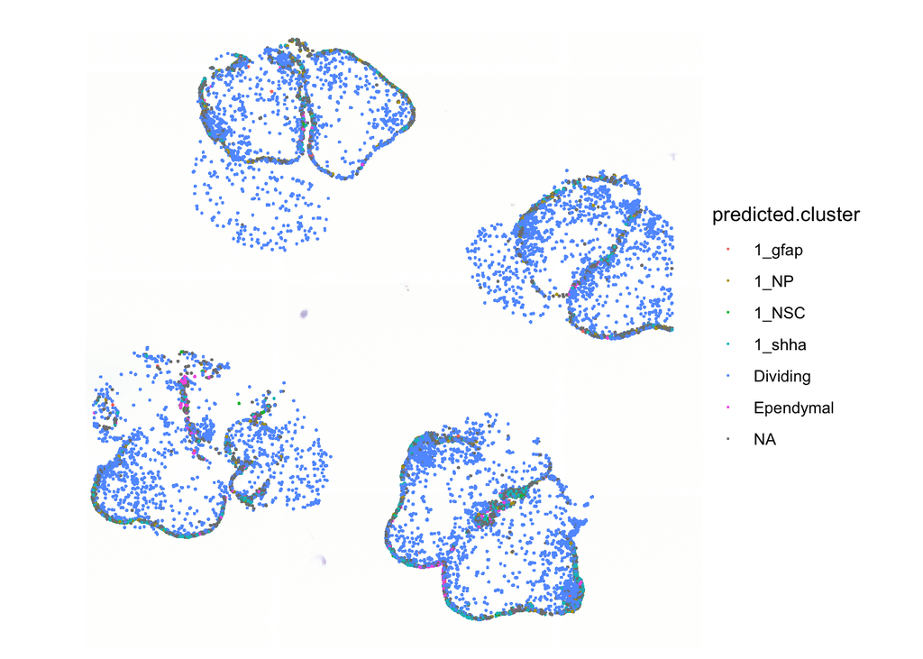

```r
SpatialDimPlot(vis_rgc, group.by = 'predicted.cluster',
               images = 's_6P17.polygons',
               pt.size.factor = 0.7)
```

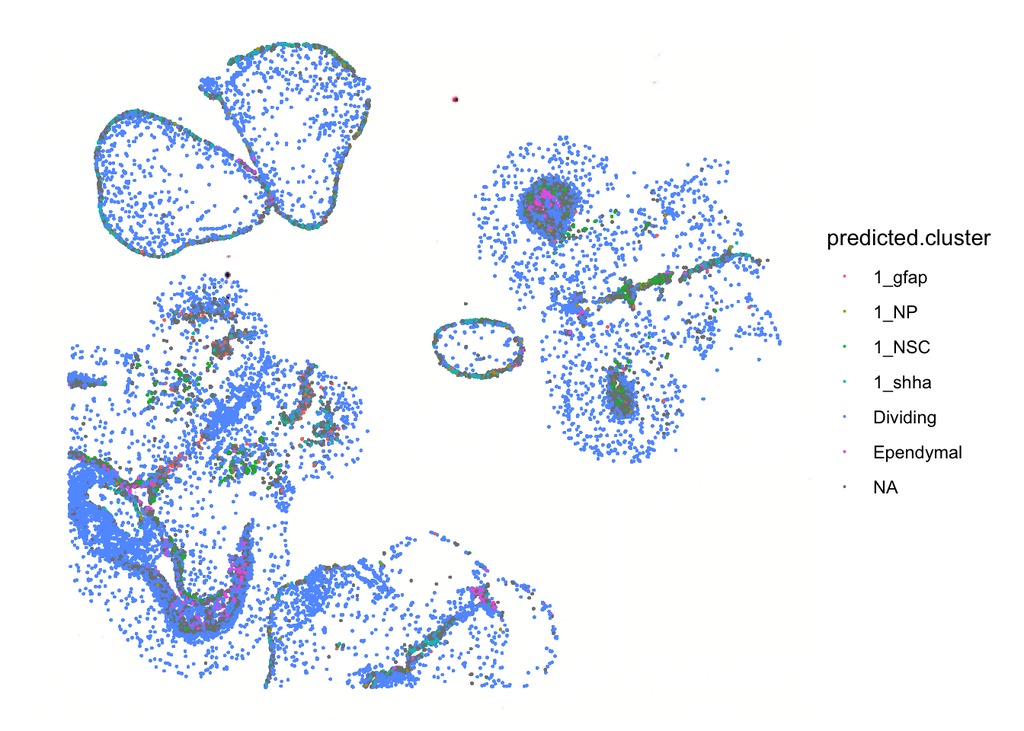

```r
SpatialDimPlot(vis_rgc, group.by = 'predicted.cluster',
               images = 's_4P10.polygons',
               pt.size.factor = 0.7)
```

1_1 seems to be more posterior

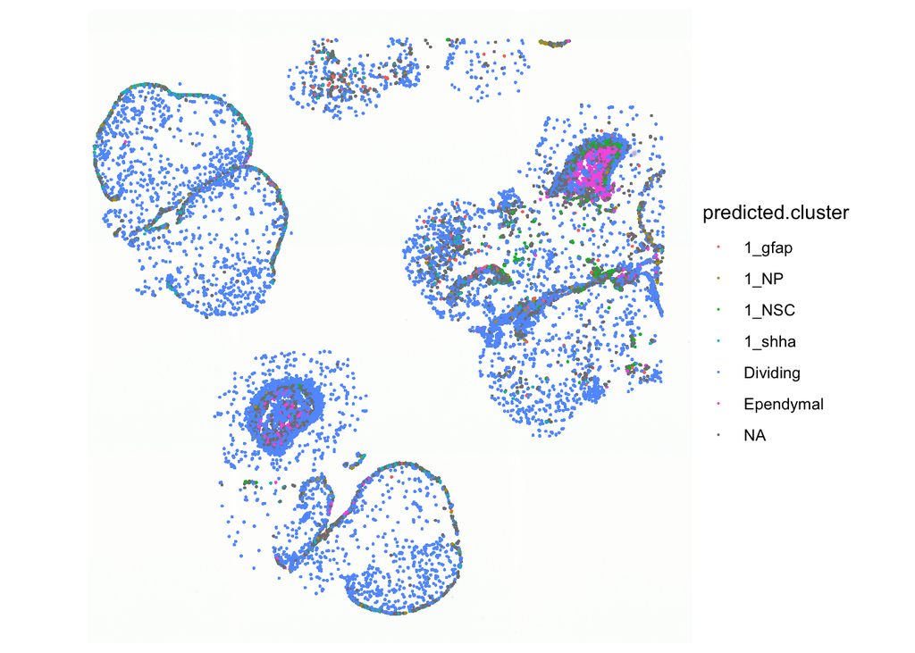

```r
SpatialDimPlot(vis_rgc, group.by = 'predicted.cluster',
               images = 's_3P5.polygons',
               pt.size.factor = 0.7)
```

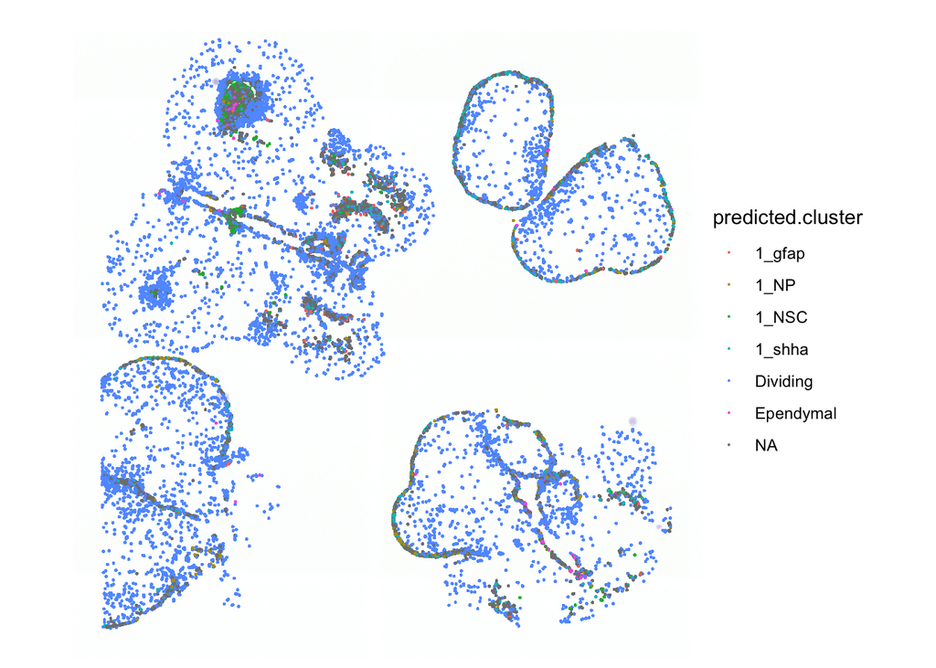

```r
SpatialDimPlot(vis_rgc, group.by = 'predicted.cluster',
               images = 's_4P5.polygons',
                              pt.size.factor = 0.7)
```